# Climate Figures

2026-04-01

# Libraries Data Cleaning and Setup

```r
library(tidyverse)
library(dplyr)
library(sf)
library(lubridate)
library(mgcv)
library(lme4)
library(reshape2)
library(readr)
```

```r
climate <- read_csv("beetles_with_climate.csv")
head(climate)
```

```
## # A tibble: 6 × 54
##     fid orig_fid OBJECTID DAMAGE_ARE CREATED_DA MODIFIED_D FEATURE_US OBSERVATIO
##   <dbl>    <dbl>    <dbl> <chr>      <chr>      <chr>      <chr>      <chr>
## 1     1        1       61 199820063… <NA>       <NA>       <NA>       <NA>
## 2     2        2       69 199820041… <NA>       <NA>       <NA>       <NA>
## 3     3        3      114 199820038… <NA>       <NA>       <NA>       <NA>
## 4     4        4      157 199820042… <NA>       <NA>       <NA>       <NA>
## 5     5        5      180 199820043… <NA>       <NA>       <NA>       <NA>
## 6     6        6      271 199920078… <NA>       <NA>       <NA>       <NA>
## # ℹ 46 more variables: REGION_ID <dbl>, LABEL <chr>, HOST_CODE <dbl>,
## #   HOST <chr>, HOST_GROUP <dbl>, HOST_GRO_1 <chr>, DCA_CODE <dbl>,
## #   DCA_COMMON <chr>, DAMAGE_TYP <dbl>, DAMAGE_T_1 <chr>, PERCENT_AF <dbl>,
## #   PERCENT__1 <chr>, PERCENT_MI <dbl>, PERCENT_MA <dbl>, PERCENT__2 <dbl>,
## #   NOTES <chr>, OBSERVAT_1 <chr>, COLLECTION <chr>, SNAPGRID_R <lgl>,
## #   SNAPGRID_C <lgl>, AREA_TYPE <chr>, ACRES <dbl>, STATUS <dbl>,
## #   SURVEY_YEA <dbl>, LEGACY_SEV <dbl>, LEGACY_S_1 <chr>, LEGACY_PAT <dbl>, …
```

```r
climate_clean <- climate %>%
  mutate(
    SURVEY_YEAR = as.numeric(SURVEY_YEA),
    ACRES = as.numeric(ACRES),
    PERCENT_MID = as.numeric(PERCENT_MI)
  ) %>%
  select(-CREATED_DA, -MODIFIED_D,
         -FEATURE_US, -OBSERVATIO,
         -NOTES, -COLLECTION,
         -SNAPGRID_R, -SNAPGRID_C,
         -HOST_GROUP, -HOST_CODE,
         -LABEL, -DAMAGE_ARE,
         -HOST_GRO_1, -DCA_CODE,
         -OBSERVAT_1, -AREA_TYPE,
         -STATUS, -GRP, -OBSERVAT_2,
         -DATA_SOURC, -IDS_DATA_S,
         -SHAPE_Leng, -SHAPE_Area,
         -LEGACY_PAT, -LEGACY_P_1,
         -LEGACY_TPA, -LEGACY_NO_,
         -LEGACY_FOR, -LEGACY_F_1) %>%
  filter(DCA_COMMON == "mountain pine beetle", HOST == "ponderosa pine", DAMAGE_T_1 == "Mortality")
head(climate_clean)
```

```
## # A tibble: 6 × 27
##     fid orig_fid OBJECTID REGION_ID HOST        DCA_COMMON DAMAGE_TYP DAMAGE_T_1
##   <dbl>    <dbl>    <dbl>     <dbl> <chr>       <chr>           <dbl> <chr>
## 1     1        1       61         2 ponderosa … mountain …          2 Mortality
## 2     2        2       69         2 ponderosa … mountain …          2 Mortality
## 3     3        3      114         2 ponderosa … mountain …          2 Mortality
## 4     4        4      157         2 ponderosa … mountain …          2 Mortality
## 5     5        5      180         2 ponderosa … mountain …          2 Mortality
## 6     7        7      279         2 ponderosa … mountain …          2 Mortality
## # ℹ 19 more variables: PERCENT_AF <dbl>, PERCENT__1 <chr>, PERCENT_MI <dbl>,
## #   PERCENT_MA <dbl>, PERCENT__2 <dbl>, ACRES <dbl>, SURVEY_YEA <dbl>,
## #   LEGACY_SEV <dbl>, LEGACY_S_1 <chr>, US_AREA <chr>, tmean <dbl>, tmax <dbl>,
## #   tmin <dbl>, tdmean <dbl>, ppt <dbl>, vpdmin <dbl>, vpdmax <dbl>,
## #   SURVEY_YEAR <dbl>, PERCENT_MID <dbl>
```

# Non-Climate Plots

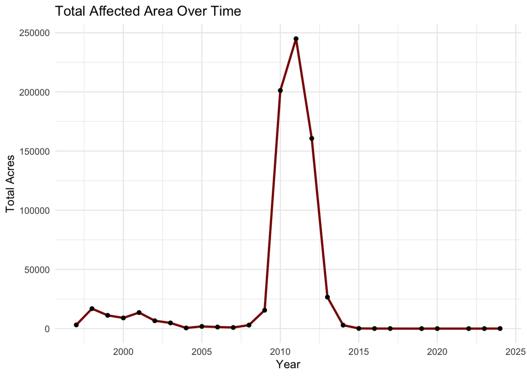

```r
total_affected <- climate_clean %>%
  group_by(SURVEY_YEA) %>%
  summarise(total_acres = sum(ACRES, na.rm = TRUE)) %>%
  ggplot(aes(x = SURVEY_YEA, y = total_acres)) +
  geom_line(color = "darkred", linewidth = 1) +
  geom_point() +
  labs(title = "Total Affected Area Over Time",
       x = "Year", y = "Total Acres") +
  theme_minimal()

total_affected
```

**Summary**

- shows how the total area of forest affected by mortality changes over time

- each point represents the summed acres impacted in a given survey year

- line highlights trends in outbreak dynamics

- huge spike and then it flat lines (which may be due to lack of data)

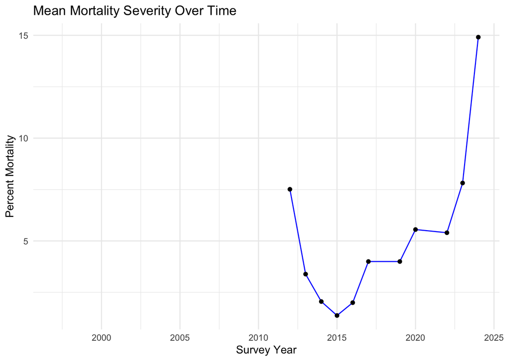

```r
mortality <- climate_clean %>%
  group_by(SURVEY_YEA) %>%
  summarise(mean_mortality = mean(PERCENT_MI, na.rm = TRUE)) %>%
  ggplot(aes(SURVEY_YEA, mean_mortality)) +
  geom_line(color = "blue") +
  geom_point() +
  labs(title = "Mean Mortality Severity Over Time",
       y = "Percent Mortality", x = "Survey Year") +
  theme_minimal()
mortality
```

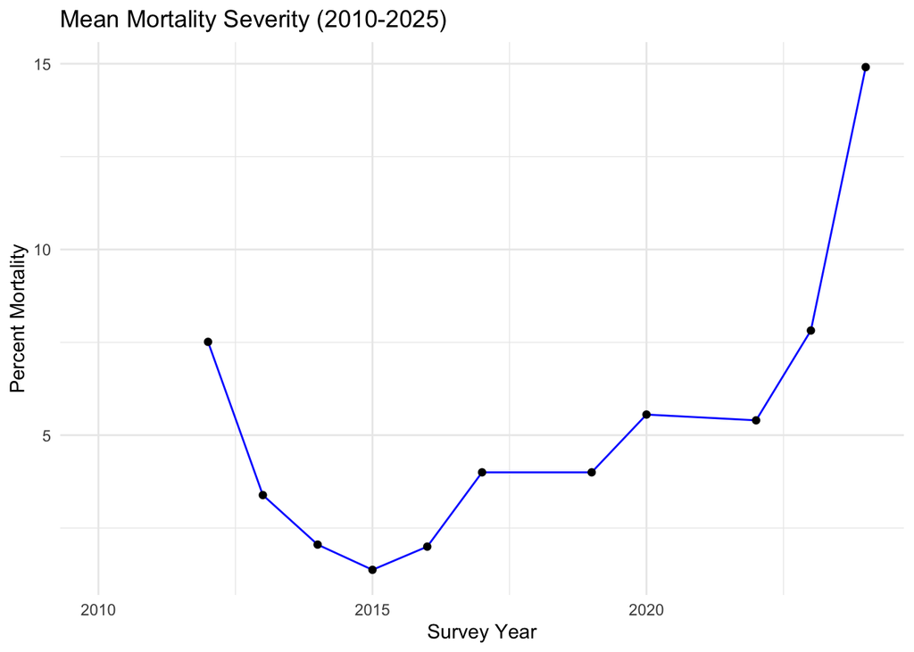

```r
mortality_zoom <- climate_clean %>%
  filter(SURVEY_YEA >= 2010 & SURVEY_YEA <= 2025) %>%
  group_by(SURVEY_YEAR) %>%
  summarise(mean_mortality = mean(PERCENT_MI, na.rm = TRUE)) %>%
  ggplot(aes(x = SURVEY_YEAR, y = mean_mortality)) +
  geom_line(color = "blue") +
  geom_point() +
  labs(title = "Mean Mortality Severity (2010-2025)",
       y = "Percent Mortality", x = "Survey Year") +
  theme_minimal()
mortality_zoom
```

**Summary**

- average mortality severity of ponderosa pines from 2010 to 2025

- highlights year-to-year trends, whether the outbreak was intensifying, stabilizing, or declining during that period

- shape looks decent

- the second one is the same just zoomed in

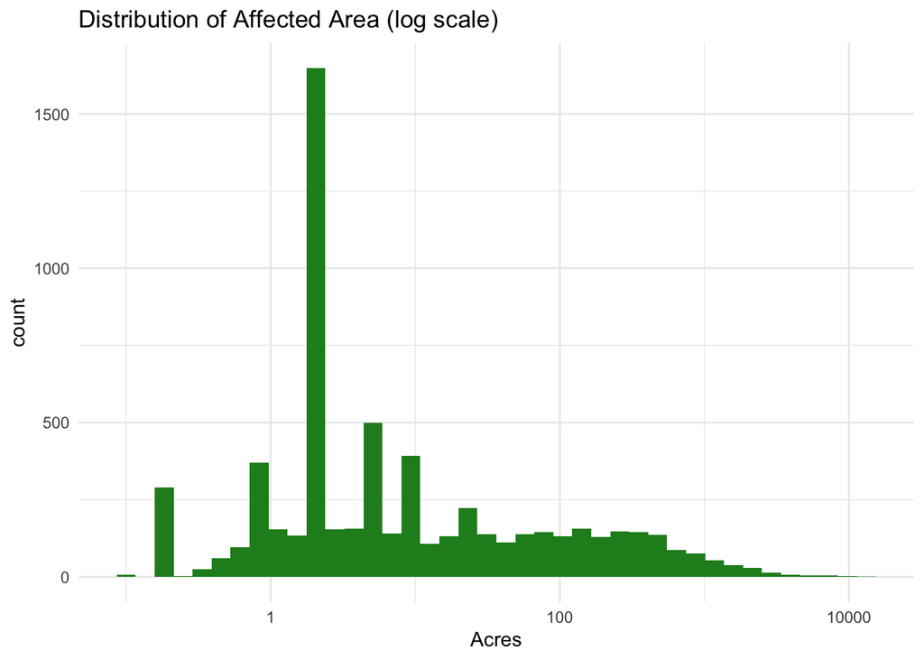

```r
ggplot(climate_clean, aes(x = ACRES)) +
  geom_histogram(bins = 40, fill = "forestgreen") +
  scale_x_log10() +
  labs(title = "Distribution of Affected Area (log scale)", x = "Acres") +
  theme_minimal()
```

**Summary**

- distribution of individual affected areas across all observations

- log scale to account for the wide range of sizes

- reveals that most mortality events impact relatively small areas

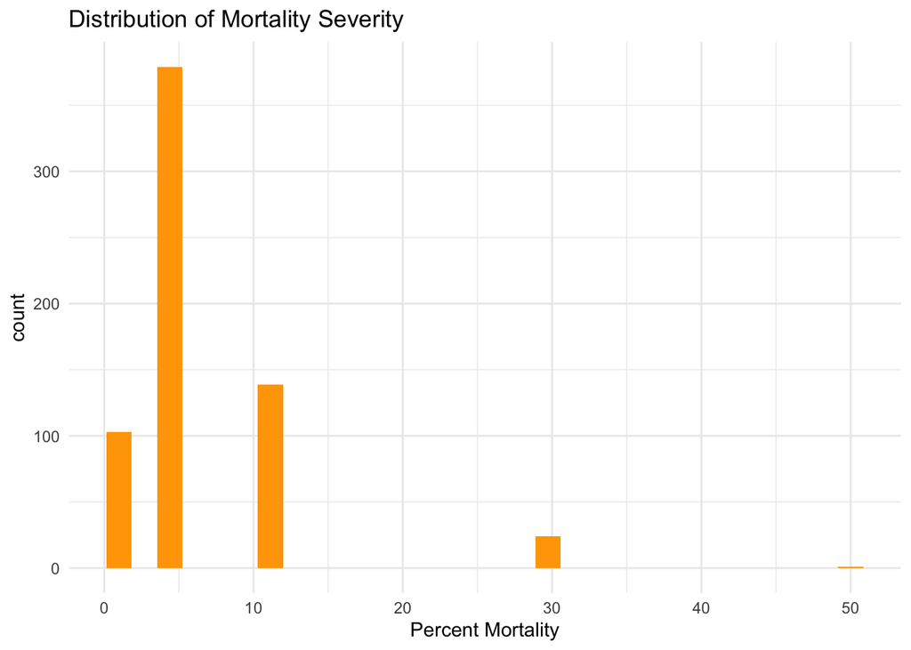

```r
ggplot(climate_clean, aes(x = PERCENT_MI)) +
  geom_histogram(bins = 30, fill = "orange") +
  labs(title = "Distribution of Mortality Severity", x = "Percent Mortality") +
  theme_minimal()
```

```r
# Percent Mid = Affected range mid point
```

**Summary**

- shows how mortality severity (PERCENT_MID) is distributed

- indicates that most observations have low to moderate mortality

- high-severity events are less common

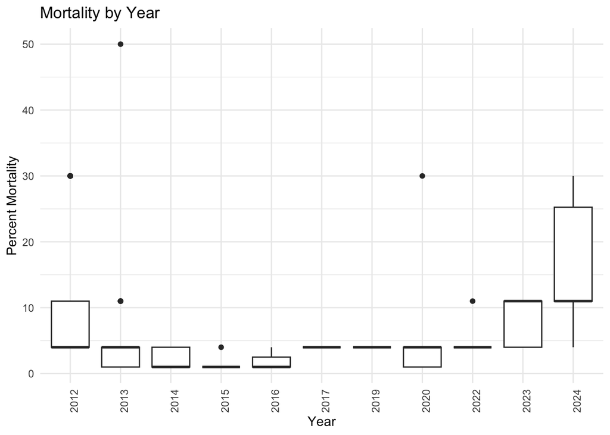

```r
ggplot(climate_clean %>% filter(!is.na(PERCENT_MI)),
       aes(x = factor(SURVEY_YEA), y = PERCENT_MI)) +
  geom_boxplot() +
  labs(title = "Mortality by Year",
       x = "Year", y = "Percent Mortality") +
  theme_minimal() +
  theme(axis.text.x = element_text(angle = 90))
```

**summary**

- something feels wrong here but we still have the right trend

- distribution of mortality severity each year

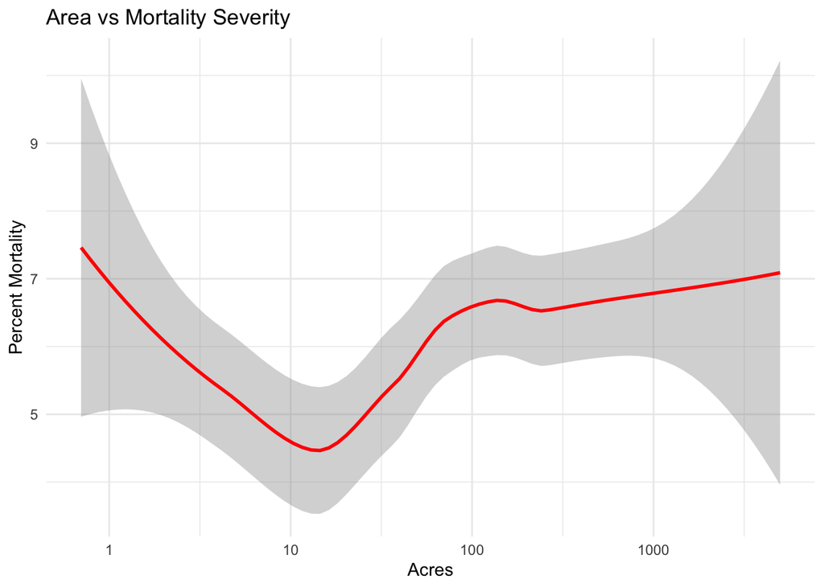

```r
ggplot(climate_clean, aes(x = ACRES, y = PERCENT_MI)) +
  scale_x_log10() +
  geom_smooth(method = "loess", color = "red") +
  labs(title = "Area vs Mortality Severity", x = "Acres", y = "Percent Mortality") +
  theme_minimal()
```

# Climate Based Plots

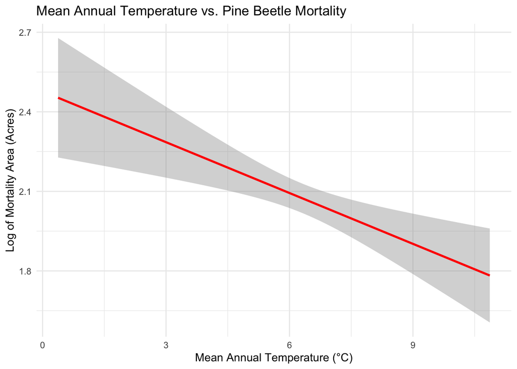

```r
ggplot(climate_clean, aes(x = tmean, y = log(ACRES))) +
  geom_smooth(method = "lm", color = "red") +
  labs(
    title = "Mean Annual Temperature vs. Pine Beetle Mortality",
    x = "Mean Annual Temperature (°C)",
    y = "Log of Mortality Area (Acres)"
  ) +
  theme_minimal()
```

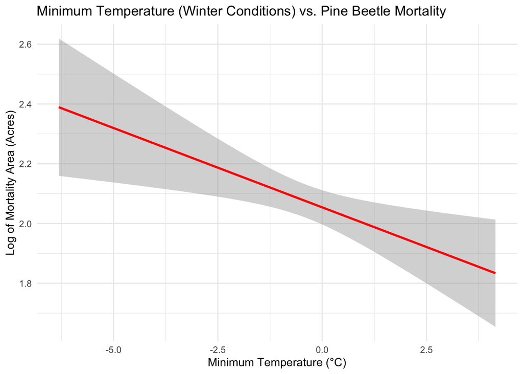

```r
ggplot(climate_clean, aes(x = tmin, y = log(ACRES))) +
  geom_smooth(method = "lm", color = "red") +
  labs(
    title = "Minimum Temperature (Winter Conditions) vs. Pine Beetle Mortality",
    x = "Minimum Temperature (°C)",
    y = "Log of Mortality Area (Acres)"
  ) +
  theme_minimal()
```

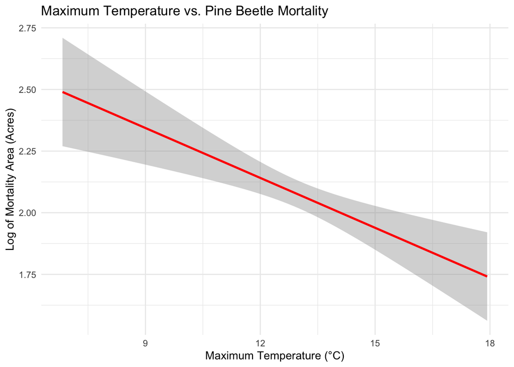

```r
ggplot(climate_clean, aes(x = tmax, y = log(ACRES))) +
  geom_smooth(method = "lm", color = "red") +
  labs(
    title = "Maximum Temperature vs. Pine Beetle Mortality",
    x = "Maximum Temperature (°C)",
    y = "Log of Mortality Area (Acres)"
  ) +
  theme_minimal()
```

**Summary**  
- mortality higher when temperature lower?? am I reading that right

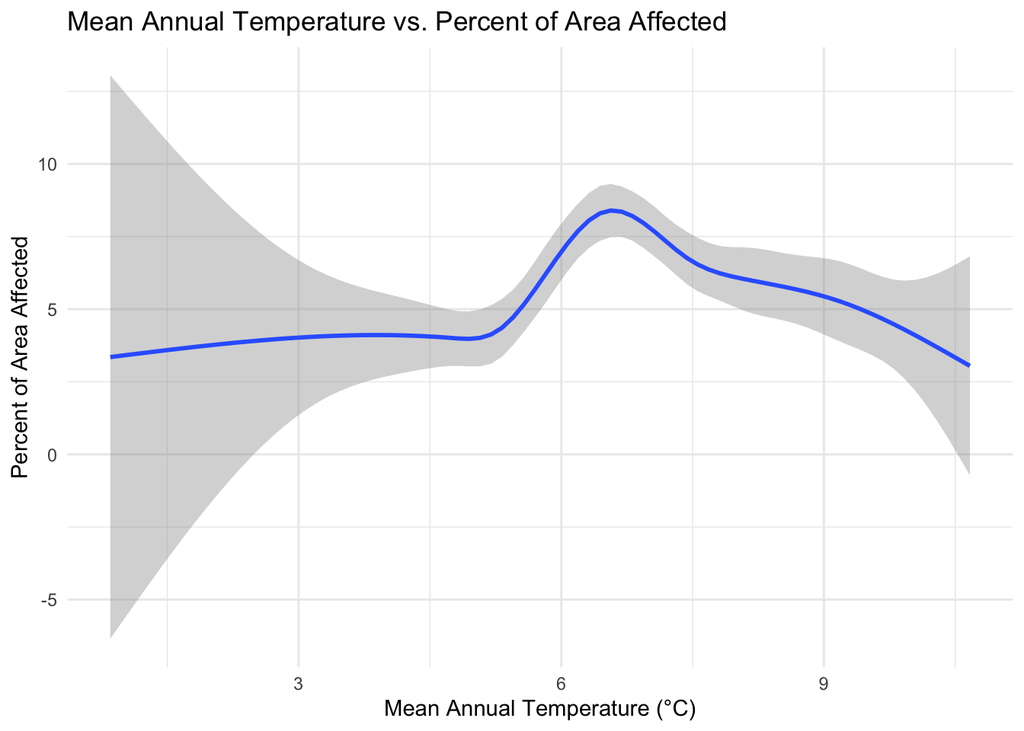

```r
ggplot(climate_clean, aes(x = tmean, y = PERCENT_MI)) +
  geom_smooth() +
  labs(
    title = "Mean Annual Temperature vs. Percent of Area Affected",
    x = "Mean Annual Temperature (°C)",
    y = "Percent of Area Affected"
  ) +
  theme_minimal()
```

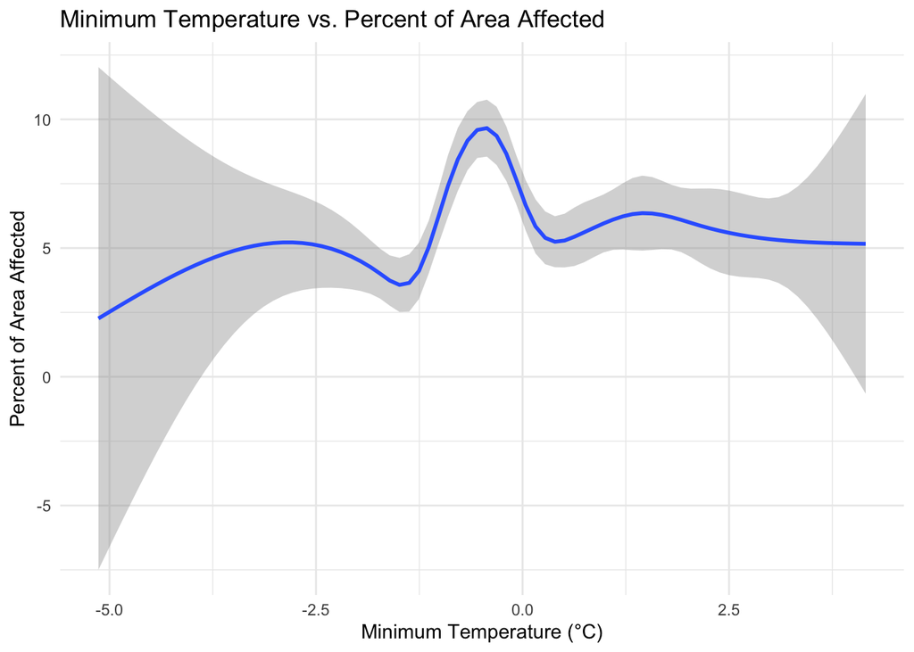

```r
ggplot(climate_clean, aes(x = tmin, y = PERCENT_MI)) +
  geom_smooth() +
  labs(
    title = "Minimum Temperature vs. Percent of Area Affected",
    x = "Minimum Temperature (°C)",
    y = "Percent of Area Affected"
  ) +
  theme_minimal()
```

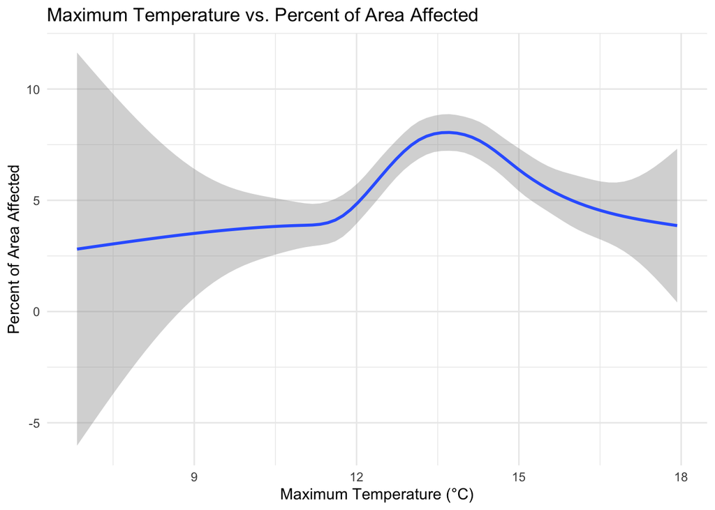

```r
ggplot(climate_clean, aes(x = tmax, y = PERCENT_MI)) +
  geom_smooth() +
  labs(
    title = "Maximum Temperature vs. Percent of Area Affected",
    x = "Maximum Temperature (°C)",
    y = "Percent of Area Affected"
  ) +
  theme_minimal()
```

**Summary**

- I think these show what the first three were trying to show better
- starts low peaks and then flattens out
- I think the minimum temperature one is the most interesting

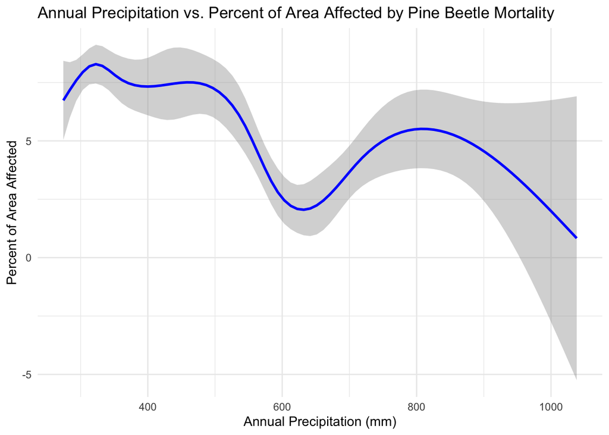

```r
ggplot(climate_clean, aes(x = ppt, y = PERCENT_MI)) +
  geom_smooth(color = "blue") +
  labs(
    title = "Annual Precipitation vs. Percent of Area Affected by Pine Beetle Mortality",
    x = "Annual Precipitation (mm)",
    y = "Percent of Area Affected"
  ) +
  theme_minimal()
```

**Summary**

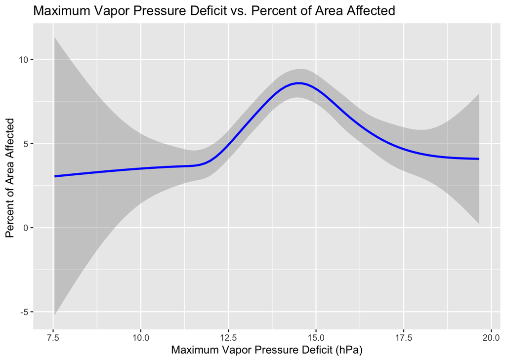

```r
ggplot(climate_clean, aes(x = vpdmax, y = PERCENT_MI)) +
  geom_smooth(color = "blue") +
  labs(
    title = "Maximum Vapor Pressure Deficit vs. Percent of Area Affected",
    x = "Maximum Vapor Pressure Deficit (hPa)",
    y = "Percent of Area Affected "
  )
```

**Summary:**

```r
library(viridis)
```

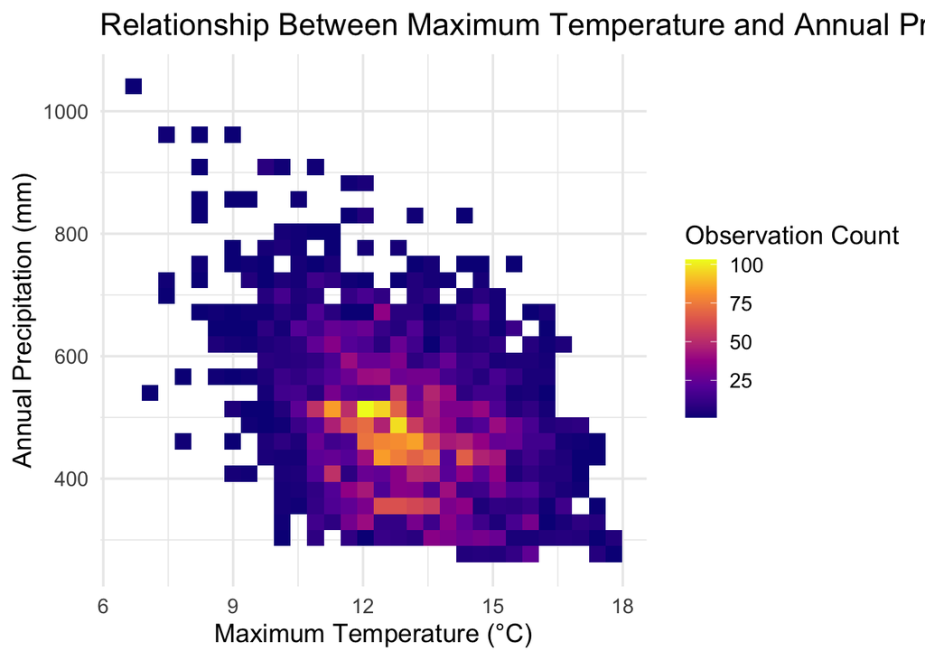

```r
ggplot(climate_clean, aes(x = tmax, y = ppt)) +
  geom_bin2d() +
  scale_fill_viridis_c(option = "C", name = "Observation Count") +
  labs(
    title = "Relationship Between Maximum Temperature and Annual Precipitation",
    x = "Maximum Temperature (°C)",
    y = "Annual Precipitation (mm)"
  ) +
  theme_minimal(base_size = 14)
```

**Summary :**

- There seems to be a temperature and percip sweet spot for beetle activity

# Models

```r
climate_model <- climate_clean %>%
  filter(!is.na(ACRES), !is.na(tmean), !is.na(ppt), !is.na(vpdmax)) %>%
  mutate(
    log_acres = log(ACRES),
    SURVEY_YEAR = as.numeric(SURVEY_YEAR)
  )
```

```r
lm <- lm(
  log(ACRES) ~
    tmean +
    tmin +
    tmax +
    ppt +
    vpdmax,
  data = climate_clean
)

summary(lm)
```

```
##
## Call:
## lm(formula = log(ACRES) ~ tmean + tmin + tmax + ppt + vpdmax,
##     data = climate_clean)
##
## Residuals:
##     Min      1Q  Median      3Q     Max
## -4.6180 -1.5516 -0.6746  1.4913  7.2599
##
## Coefficients:
##               Estimate Std. Error t value Pr(>|t|)
## (Intercept)  1.671e+00  8.409e-01   1.987   0.0469 *
## tmean        3.772e+01  6.924e+01   0.545   0.5860
## tmin        -1.883e+01  3.463e+01  -0.544   0.5866
## tmax        -1.954e+01  3.462e+01  -0.565   0.5724
## ppt          1.632e-03  3.845e-04   4.245 2.22e-05 ***
## vpdmax       6.441e-01  6.724e-02   9.579  < 2e-16 ***
## ---
## Signif. codes:  0 '***' 0.001 '**' 0.01 '*' 0.05 '.' 0.1 ' ' 1
##
## Residual standard error: 2.225 on 6271 degrees of freedom
## Multiple R-squared:  0.01741,    Adjusted R-squared:  0.01663
## F-statistic: 22.22 on 5 and 6271 DF,  p-value: < 2.2e-16
```

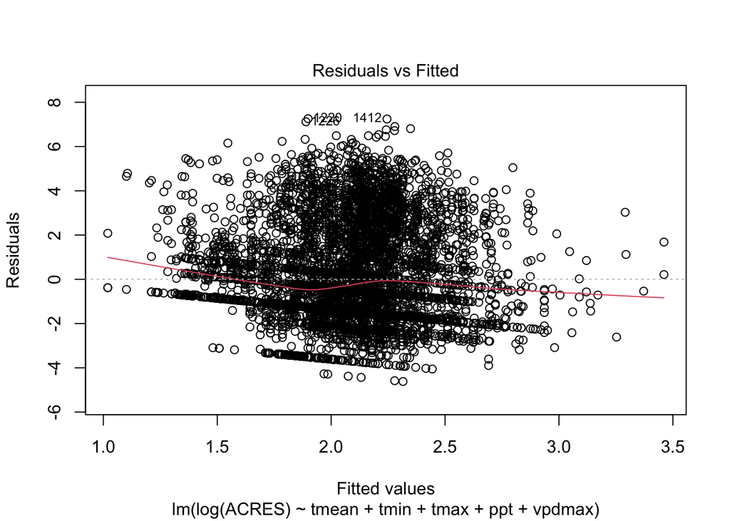

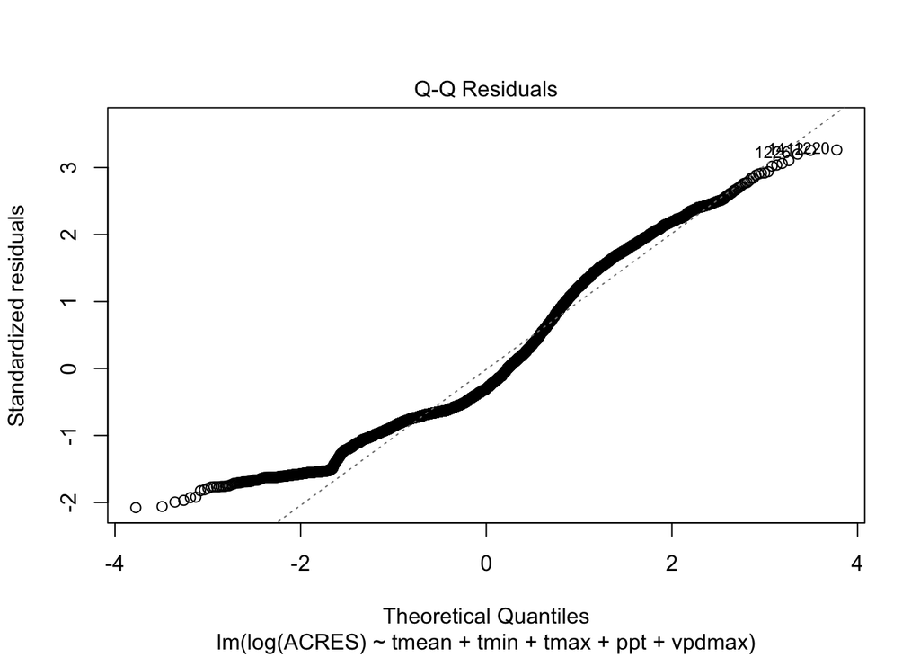

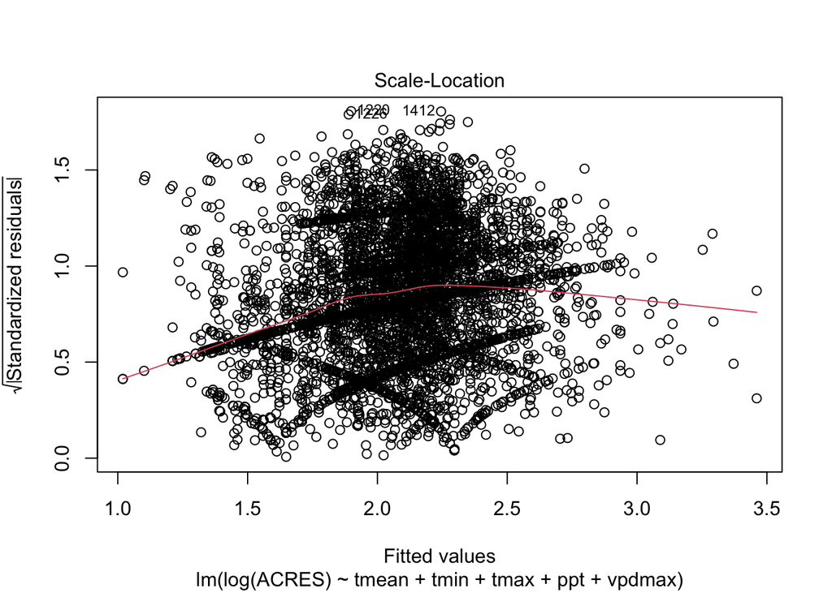

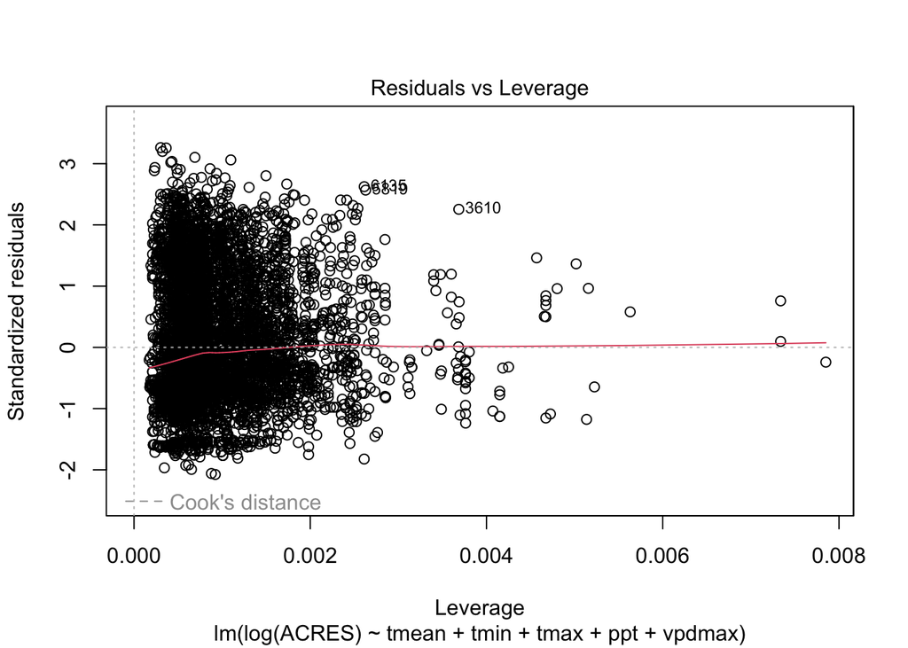

```r
plot(lm, pages = 4)
```

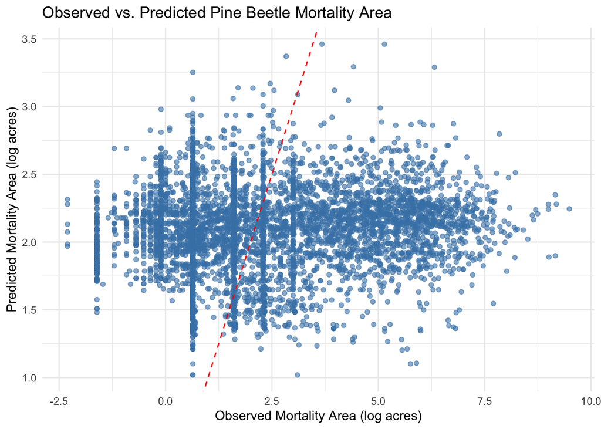

```r
climate_clean$pred_log_acres <- predict(lm, newdata = climate_clean)

ggplot(climate_clean, aes(x = log(ACRES), y = pred_log_acres)) +
  geom_point(alpha = 0.6, color = "steelblue") +
  geom_abline(slope = 1, intercept = 0, linetype = "dashed", color = "red") +
  labs(
    title = "Observed vs. Predicted Pine Beetle Mortality Area",
    x = "Observed Mortality Area (log acres)",
    y = "Predicted Mortality Area (log acres)"
  ) +
  theme_minimal()
```

```r
gam_model <- gam(
  log_acres ~
    s(tmean) +
    s(ppt) +
    s(vpdmax) +
    s(tmin) +
    s(SURVEY_YEAR),
  data = climate_model,
  method = "REML"
)

summary(gam_model)
```

```
##
## Family: gaussian
## Link function: identity
##
## Formula:
## log_acres ~ s(tmean) + s(ppt) + s(vpdmax) + s(tmin) + s(SURVEY_YEAR)
##
## Parametric coefficients:
##             Estimate Std. Error t value Pr(>|t|)
## (Intercept)  2.07451    0.02234   92.86   <2e-16 ***
## ---
## Signif. codes:  0 '***' 0.001 '**' 0.01 '*' 0.05 '.' 0.1 ' ' 1
##
## Approximate significance of smooth terms:
##                  edf Ref.df       F  p-value
## s(tmean)       6.594  7.758   7.930  < 2e-16 ***
## s(ppt)         1.001  1.003  14.967 0.000110 ***
## s(vpdmax)      4.506  5.775   4.565 0.000198 ***
## s(tmin)        8.041  8.659   5.570  < 2e-16 ***
## s(SURVEY_YEAR) 8.962  8.999 375.084  < 2e-16 ***
## ---
## Signif. codes:  0 '***' 0.001 '**' 0.01 '*' 0.05 '.' 0.1 ' ' 1
##
## R-sq.(adj) =  0.378   Deviance explained = 38.1%
## -REML =  12556  Scale est. = 3.1326    n = 6277
```

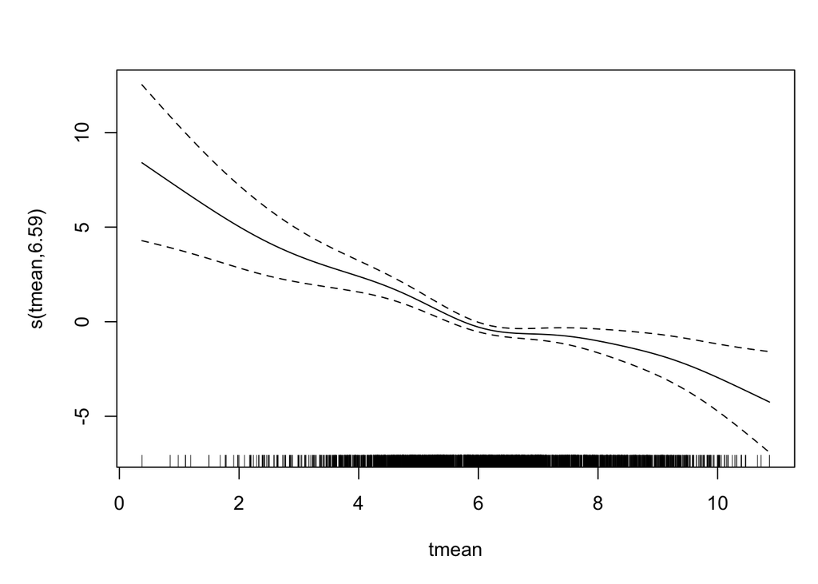

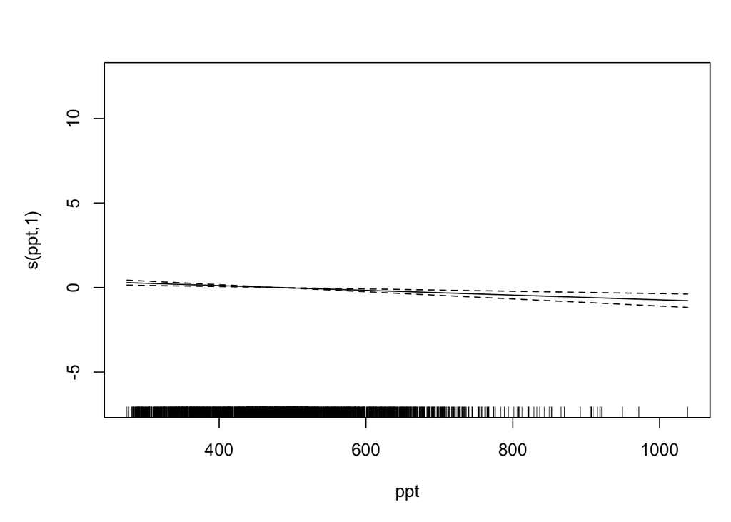

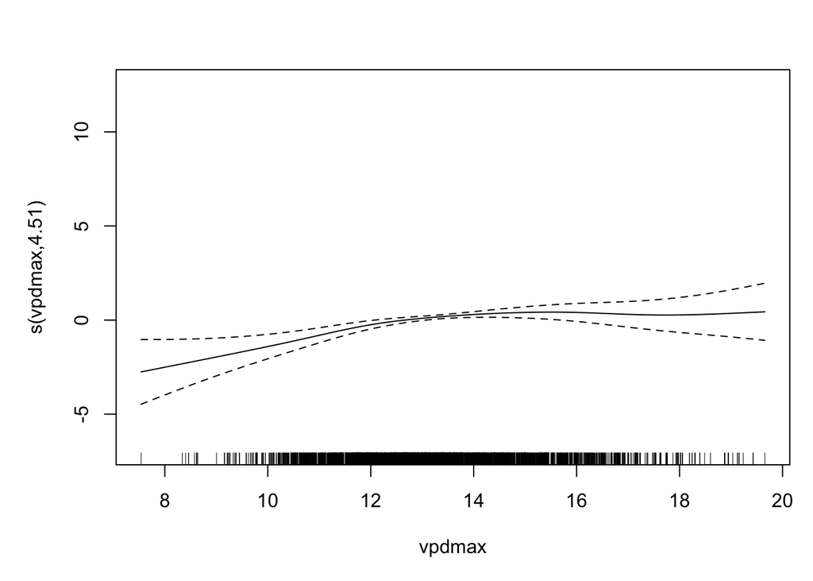

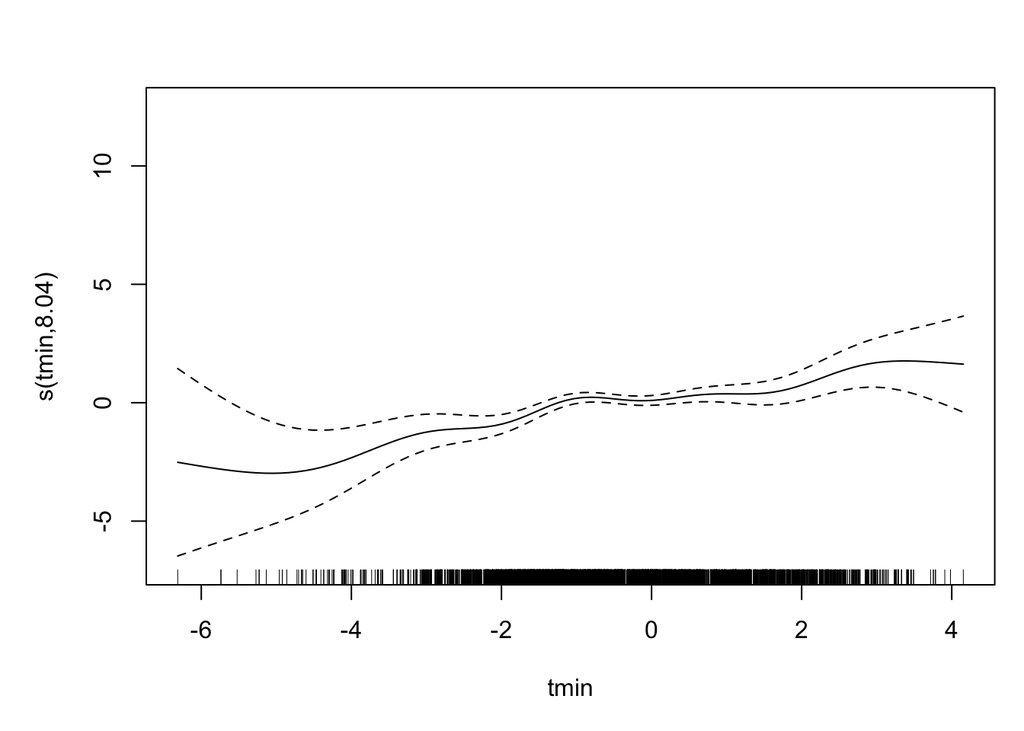

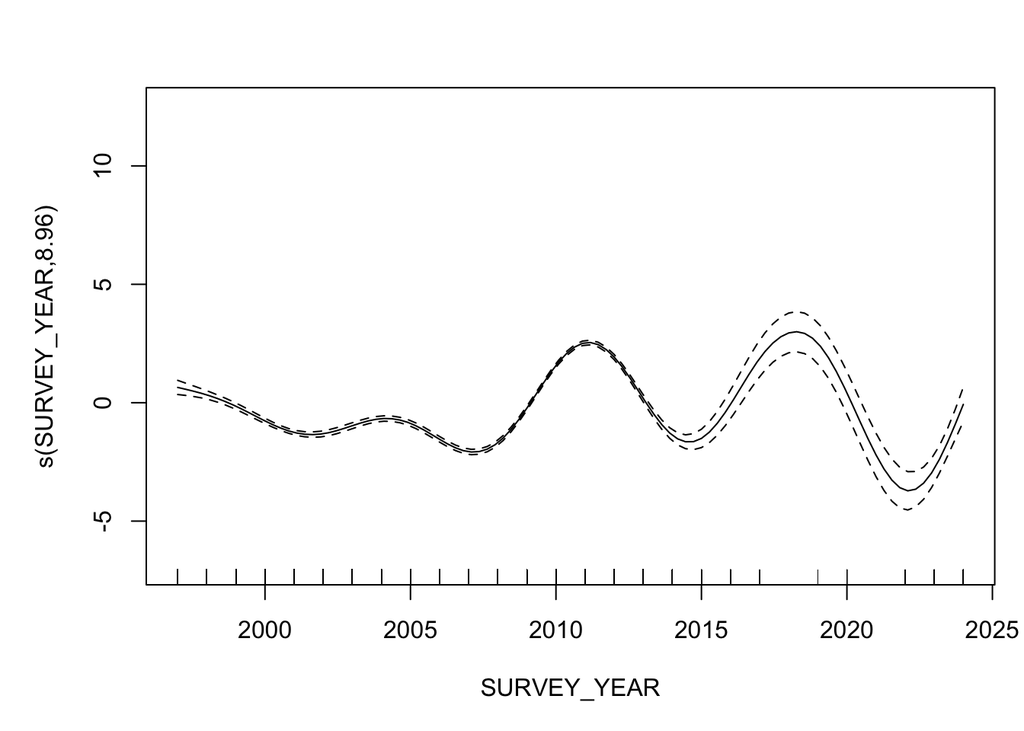

```r
plot(gam_model, pages = 5)
```

```r
library(gratia)
gam_model2 <- gam(
  log_acres ~
    te(tmean, ppt) +
    s(vpdmax) +
    s(SURVEY_YEAR),
  data = climate_model,
  method = "REML"
)

summary(gam_model2)
```

```
##
## Family: gaussian
## Link function: identity
##
## Formula:
## log_acres ~ te(tmean, ppt) + s(vpdmax) + s(SURVEY_YEAR)
##
## Parametric coefficients:
##             Estimate Std. Error t value Pr(>|t|)
## (Intercept)  2.07451    0.02232   92.93   <2e-16 ***
## ---
## Signif. codes:  0 '***' 0.001 '**' 0.01 '*' 0.05 '.' 0.1 ' ' 1
##
## Approximate significance of smooth terms:
##                   edf Ref.df       F p-value
## te(tmean,ppt)  16.103 18.353  10.963  <2e-16 ***
## s(vpdmax)       5.685  7.030   2.431  0.0173 *
## s(SURVEY_YEAR)  8.961  8.999 349.364  <2e-16 ***
## ---
## Signif. codes:  0 '***' 0.001 '**' 0.01 '*' 0.05 '.' 0.1 ' ' 1
##
## R-sq.(adj) =  0.379   Deviance explained = 38.2%
## -REML =  12544  Scale est. = 3.128     n = 6277
```

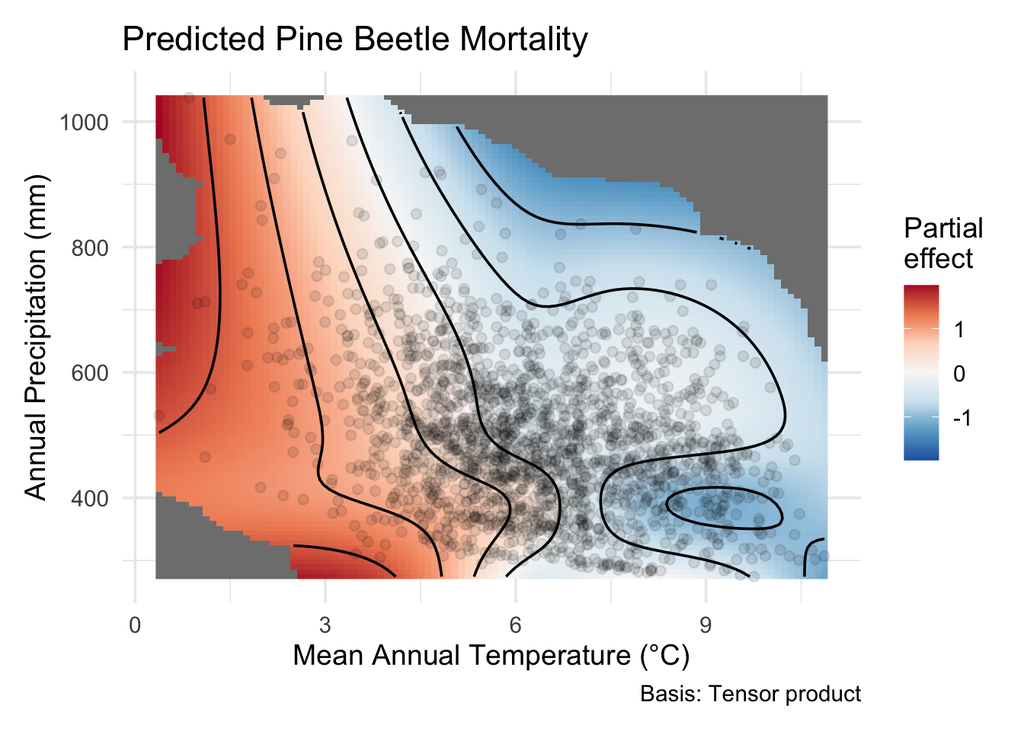

```r
draw(gam_model2, select = 1) +
  labs(
    title = "Predicted Pine Beetle Mortality",
    x = "Mean Annual Temperature (°C)",
    y = "Annual Precipitation (mm)",
    fill = "Predicted Mortality\n(log acres)"
  ) +
  theme_minimal(base_size = 14)
```

```r
gamm(
  log_acres ~ te(tmean, ppt) + s(vpdmax) + s(SURVEY_YEAR),
  random = list(REGION_ID = ~1),
  data = climate_model
)
```

```
## $lme
## Linear mixed-effects model fit by maximum likelihood
##   Data: strip.offset(mf)
##   Log-likelihood: -12546.61
##   Fixed: y ~ X - 1
##       X(Intercept)  Xte(tmean,ppt)Fx1  Xte(tmean,ppt)Fx2  Xte(tmean,ppt)Fx3
##         2.07450748         3.51583960         3.00190349        -2.49264757
##      Xs(vpdmax)Fx1 Xs(SURVEY_YEAR)Fx1
##        -0.00244264        -7.60007477
##
## Random effects:
##  Formula: ~Xr - 1 | g
##  Structure: pdTens
##              Xr1      Xr2      Xr3     Xr4     Xr5      Xr6      Xr7     Xr8
## StdDev: 26.33184 16.70936 22.82212 14.0586 13.8844 18.56072 23.14632 23.2371
##              Xr9     Xr10     Xr11     Xr12     Xr13    Xr14     Xr15    Xr16
## StdDev: 16.75385 8.105026 7.254099 7.190972 7.051855 4.48514 4.103619 4.14148
##             Xr17      Xr18     Xr19    Xr20      Xr21
## StdDev: 1.723756 0.9608584 1.274027 1.49779 0.9681812
##
##  Formula: ~Xr.0 - 1 | g.0 %in% g
##  Structure: pdIdnot
##            Xr.01    Xr.02    Xr.03    Xr.04    Xr.05    Xr.06    Xr.07    Xr.08
## StdDev: 2.047982 2.047982 2.047982 2.047982 2.047982 2.047982 2.047982 2.047982
##
##  Formula: ~Xr.1 - 1 | g.1 %in% g.0 %in% g
##  Structure: pdIdnot
##            Xr.11    Xr.12    Xr.13    Xr.14    Xr.15    Xr.16    Xr.17    Xr.18
## StdDev: 52.73209 52.73209 52.73209 52.73209 52.73209 52.73209 52.73209 52.73209
##
##  Formula: ~1 | REGION_ID %in% g.1 %in% g.0 %in% g
##          (Intercept) Residual
## StdDev: 3.823627e-05 1.768402
##
## Number of Observations: 6277
## Number of Groups:
##                                  g                         g.0 %in% g
##                                  1                                  1
##                g.1 %in% g.0 %in% g REGION_ID %in% g.1 %in% g.0 %in% g
##                                  1                                  1
##
## $gam
##
## Family: gaussian
## Link function: identity
##
## Formula:
## log_acres ~ te(tmean, ppt) + s(vpdmax) + s(SURVEY_YEAR)
##
## Estimated degrees of freedom:
## 15.59  5.31  8.96  total = 30.87
##
##
## attr(,"class")
## [1] "gamm" "list"
```

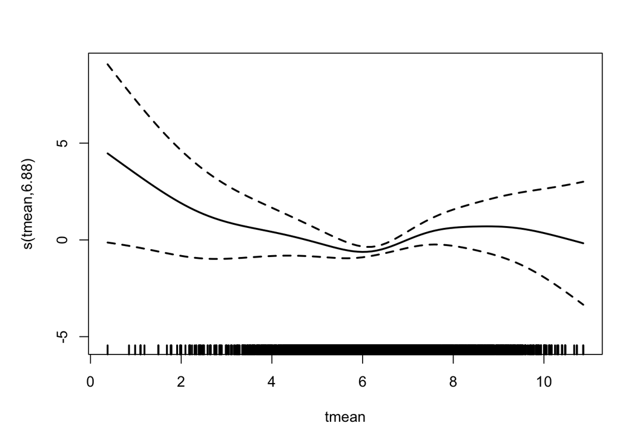

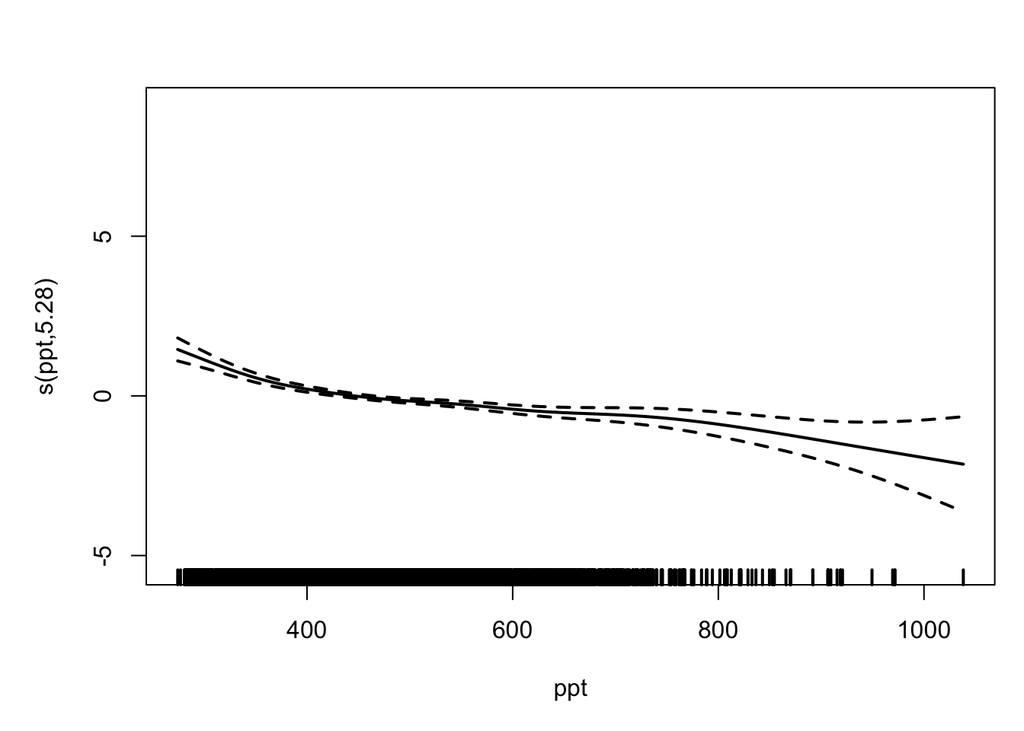

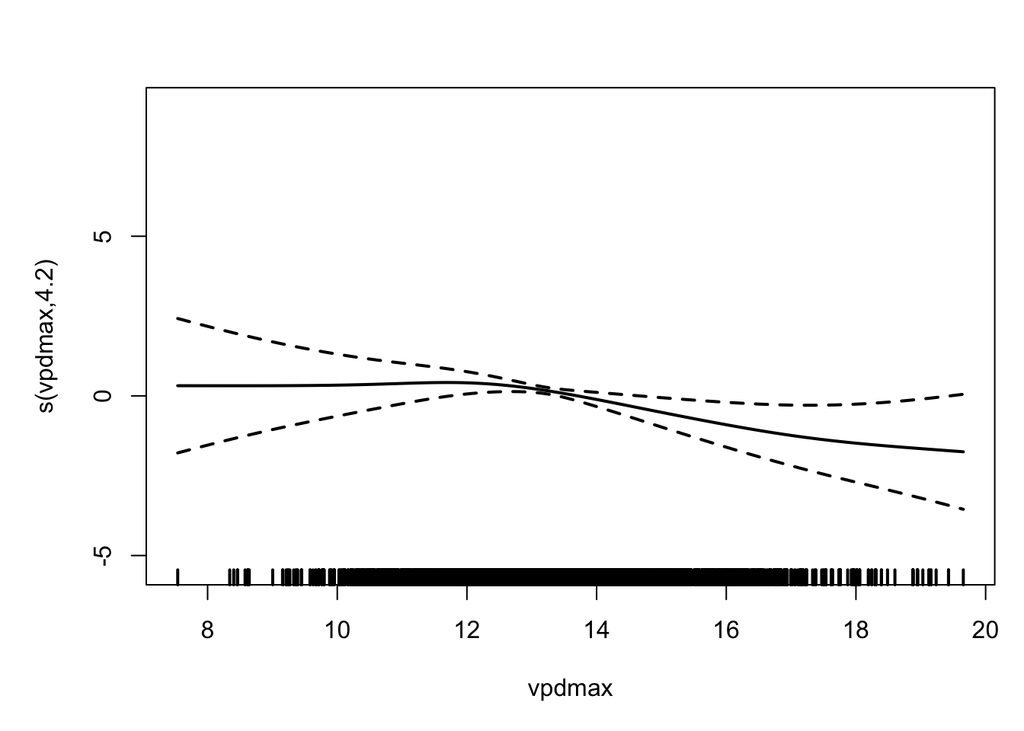

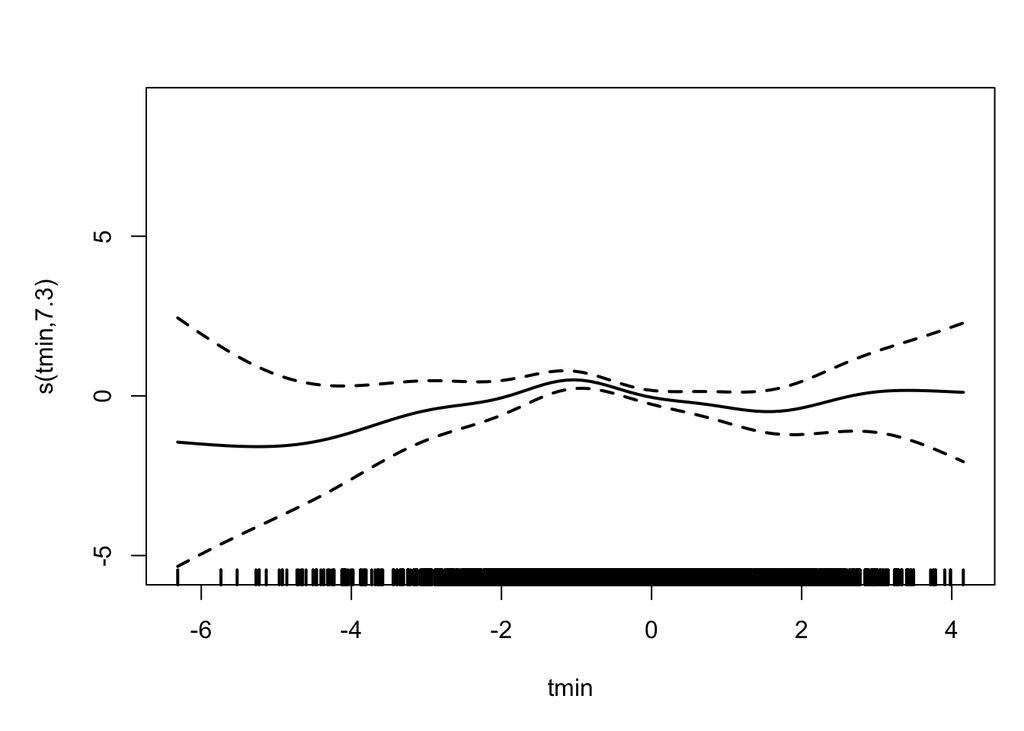

```r
gamm_model <- gamm(
  log_acres ~
    s(tmean) +
    s(ppt) +
    s(vpdmax) +
    s(tmin),
  random = list(SURVEY_YEAR = ~1),
  data = climate_model,
  method = "REML"
)

par(mfrow = c(2, 2))  # bigger panels
plot(gamm_model$gam,
     cex = 1.2,
     lwd = 2, pages = 4)
```